# Python可视化期末作业

- 期末作业要求
- 前言
- 数据获取
- 数据预处理
- 描述性统计
- 利用pyecharts可视化

## 期末作业要求

以下题目任选其一，也可以自行选择方向：

1. 可视化看从“丝绸之路”到“一带一路”
2. 新质生产力词云图
3. 红楼梦人物关系图
4. 各省富裕度指数可视化
5. 全球GDP变迁
6. 现代交通网络
7. 厦门美食地图

8月4日前，连同作业一起交到邮箱 chiyuhan@xmu.edu.cn

平日作业格式：.ipynb .py

期末作业格式：代码写在.ipynb 或.py文件里，可视化图可以html方式给出，或者嵌在.ipynb文件里。

## 前言

本文档是《Python数据获取、处理和可视化》的课程作业，选题是“大型量化私募管理规模的地域分布统计”。这段时间在找量化私募的实习，之前进小私募实习吃了点亏，所以我比较看重其管理规模。一般来讲，小私募管理不太规范，路子比较野；大私募无论管理、风控都做的更好。但多小算小，多大算大呢？回答了这个问题以后，大私募在地域上又呈现怎样的分布呢？

于是我想到从[证券基金业协会](https://www.amac.org.cn/)上将私募机构信息用爬虫抓取下来，先进行描述性统计，然后按地域做可视化。

## 数据获取

如果请求太频繁会被网站中断，报错信息：

```
ConnectionError: ('connection aborted.'，connectionResetError(18854，'远程主机强迫关闭了一个现有的连接。'，None，18854，None))
```

因此遍历全部链接时要分批处理

```python
# 导入必要的包
from selenium import webdriver
from selenium.common.exceptions import TimeoutException, NoSuchElementException
from selenium.webdriver.support.ui import WebDriverWait
from selenium.webdriver.support import expected_conditions as EC
from selenium.webdriver.common.by import By
from selenium.webdriver.common.action_chains import ActionChains
from selenium.webdriver.common.keys import Keys
from bs4 import BeautifulSoup
import matplotlib.pyplot as plt
import matplotlib
import requests
import concurrent.futures
import time
import pandas as pd
import numpy as np
from tqdm import tqdm
import pyecharts.options as opts
from pyecharts.globals import ThemeType
from pyecharts.commons.utils import JsCode
from pyecharts.charts import Grid, Bar, Map, Pie
```

```python
class FundScraper:
    def __init__(self, url, batch_size=100, retry_attempts=3):
        self.url = url
        self.batch_size = batch_size
        self.retry_attempts = retry_attempts
        self.links = []
        self.info_list = []
        self.failed_links = []
        self.driver = webdriver.Chrome()

    # 获取当前页面的链接
    def get_links(self):
        self.driver.get(self.url)
        time.sleep(5.1)
        self.driver.refresh()

        while True:
            rows = WebDriverWait(self.driver, 10).until(
                EC.presence_of_all_elements_located((By.XPATH, '//td[@data-dt-column="1"]'))
            )
            for row in rows:
                try:
                    a_tag = row.find_element(By.TAG_NAME, 'a')
                    href = a_tag.get_attribute('href')
                    self.links.append(href)
                except:
                    print("No <a> tag found")

            # 检查是否需要结束循环
            try:
                disabled_element = self.driver.find_element(By.XPATH, '//a[@disabled="disabled"]')
                if disabled_element and disabled_element.text == '1028':  # 最后一页
                    print("Last page")
                    break
            except:
                pass

            # 查找“下一页”按钮并点击
            try:
                next_button = WebDriverWait(self.driver, 10).until(
                    EC.element_to_be_clickable((By.XPATH, '//a[@class="paginate_button next"]'))
                )
                self.driver.execute_script("arguments[0].scrollIntoView();", next_button)
                actions = ActionChains(self.driver)
                actions.move_to_element(next_button).click().perform()
                time.sleep(0.3)
            except Exception as e:
                print(f"An error occurred: {e}")
                break

        self.driver.quit()

    @staticmethod
    def parse_html(response):
        try:
            soup = BeautifulSoup(response.content, 'html.parser')
            fund_info = {
                "基金管理人全称(中文)": None,
                "机构类型": None,
                "办公地址": None,
                "管理规模区间": None,
                "全职员工人数": None
            }

            element = soup.find('span', id='complaint2')
            if element:
                fund_info["基金管理人全称(中文)"] = element.text.strip()

            table_rows = soup.select('table.table tbody tr')
            for row in table_rows:
                cells = row.find_all('td')
                if len(cells) > 0:
                    cell_title = cells[0].get_text(strip=True)
                    cell_value = cells[1].get_text(strip=True) if len(cells) > 1 else None
                    if cell_title == "办公地址":
                        fund_info["办公地址"] = cell_value
                    elif cell_title == "管理规模区间":
                        fund_info["管理规模区间"] = cell_value
                    elif cell_title == "全职员工人数":
                        fund_info["全职员工人数"] = cell_value
                    elif cell_title == "机构类型":
                        fund_info["机构类型"] = cell_value

            return fund_info, None
        except Exception as e:
            return None, str(e)

    # 定义获取信息的函数
    def fetch_info(self, link):
        try:
            response = requests.get(link, timeout=10)
            response.raise_for_status()
            parsed_info, error = self.parse_html(response)
            return link, parsed_info, error
        except requests.RequestException as e:
            return link, None, str(e)

    def batch_links(self, links):
        for i in range(0, len(links), self.batch_size):
            yield links[i:i + self.batch_size]

    # 访问太频繁会被踢出去，将链接列表分批
    def process_links(self):
        for batch in tqdm(self.batch_links(self.links), total=len(self.links)//self.batch_size, desc='Batches'):
            with concurrent.futures.ThreadPoolExecutor() as executor:
                results = list(tqdm(executor.map(self.fetch_info, batch), total=len(batch), desc='urls'))
            for link, info, error in results:
                if info is not None:
                    self.info_list.append(info)
                else:
                    self.failed_links.append(link)

    # 处理失败的链接（可以选择重新尝试几次）
    def retry_failed_links(self):
        for attempt in range(self.retry_attempts):
            if not self.failed_links:
                break
            current_failed_links = self.failed_links
            self.failed_links = []
            for batch in tqdm(self.batch_links(current_failed_links), total=len(current_failed_links)//self.batch_size, desc=f'Retrying attempt {attempt + 1}'):
                with concurrent.futures.ThreadPoolExecutor() as executor:
                    results = list(tqdm(executor.map(self.fetch_info, batch), total=len(batch), desc='urls'))
                for link, info, error in results:
                    if info is not None:
                        self.info_list.append(info)
                    else:
                        self.failed_links.append(link)

    def run(self):
        self.get_links()
        self.process_links()
        self.retry_failed_links()
        return self.info_list

# 创建实例
url = "https://gs.amac.org.cn/amac-infodisc/res/pof/manager/managerList.html"
scraper = FundScraper(url)
fund_info_list = scraper.run()

# 导出excel
info_df = pd.DataFrame(fund_info_list)
info_df.to_excel("private_equity_list.xlsx", index=False)
```

```
Last page
```

```
Batches: 206it [11:58,  3.49s/it]
Retrying attempt 1: 1it [00:00,  5.04it/s]
```

## 数据预处理

由于私募基金分为证券基金、股权基金等，股权基金从事的是风险投资相关业务，而量化私募指的是证券基金，我们要将其筛选出来。

另外，我们还需从办公地址中提取其所在的第一行政区划（省/直辖市/自治区），基金业协会注册的机构中不含香港、澳门、台湾的机构。

针对以上两点，我们对原始数据进行预处理。

```python
info_df = pd.read_excel("private_equity_list.xlsx")
# 筛选量化私募
filtered_pe = info_df[info_df["机构类型"] == "私募证券投资基金管理人"]
# 去除重复信息
filtered_pe = filtered_pe.drop_duplicates().reset_index(drop=True)

provinces = [
    "北京市", "天津市", "河北省", "山西省", "内蒙古自治区", "辽宁省", "吉林省", "黑龙江省",
    "上海市", "江苏省", "浙江省", "安徽省", "福建省", "江西省", "山东省", "河南省",
    "湖北省", "湖南省", "广东省", "广西壮族自治区", "海南省", "重庆市", "四川省",
    "贵州省", "云南省", "西藏自治区", "陕西省", "甘肃省", "青海省", "宁夏回族自治区",
    "新疆维吾尔自治区", "香港特别行政区", "澳门特别行政区", "台湾省"
]

# 添加省份
filtered_pe["省份"] = filtered_pe["办公地址"].apply(lambda x: next((province for province in provinces if province in x), '未知'))
filtered_pe.head()
```

|  | 基金管理人全称(中文) | 机构类型 | 办公地址 | 管理规模区间 | 全职员工人数 | 省份 |
| --- | --- | --- | --- | --- | --- | --- |
| 0 | 深圳松石私募证券基金管理有限公司 | 私募证券投资基金管理人 | 广东省深圳市南山区粤海街道科技园社区科丰路2号特发信息港大厦E栋204 | 0-5亿元 | 6.0 | 广东省 |
| 1 | 浙江乾铭私募基金管理有限公司 | 私募证券投资基金管理人 | 浙江省杭州市拱墅区上塘路15号武林时代商务中心9层06-A室 | 0-5亿元 | 11.0 | 浙江省 |
| 2 | 南京水杉私募基金管理有限公司 | 私募证券投资基金管理人 | 江苏省南京市玄武区童卫路4号2号楼1楼 | 0-5亿元 | 5.0 | 江苏省 |
| 3 | 上海宸蹊私募基金管理有限公司 | 私募证券投资基金管理人 | 上海市浦东新区民生路1286号807室 | 0-5亿元 | 5.0 | 上海市 |
| 4 | 江苏华年私募基金有限公司 | 私募证券投资基金管理人 | 上海市闵行区申昆路1999号4幢209室 | 0-5亿元 | 8.0 | 上海市 |

```python
print(len(filtered_pe))
```

```
8135
```

## 描述性统计

我们首先观察私募数量在规模区间上的分布。

最后，虽然在职员工人数跟私募大小没有直接关系（往往管理百亿资金的团队只有十几人），但我们也探究下员工人数呈现怎样的分布。

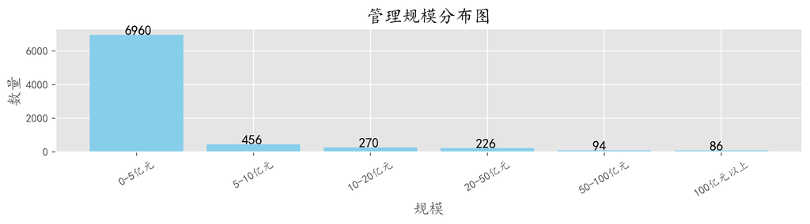

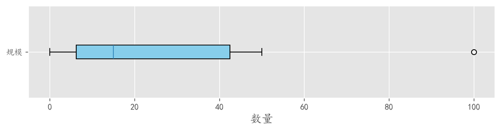

```
             规模数值
count    6.000000
mean    30.833333
std     38.264431
min      0.000000
25%      6.250000
50%     15.000000
75%     42.500000
max    100.000000
```

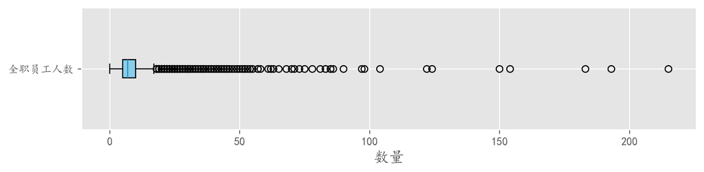

```
            全职员工人数
count  8134.000000
mean      9.003565
std       8.310160
min       0.000000
25%       5.000000
50%       7.000000
75%      10.000000
max     215.000000
```

```python
class FundScaleAnalysis:
    def __init__(self, data):
        self.data = data
        self.grouped = None

    def group_data(self):
        self.grouped = self.data["管理规模区间"].value_counts().reset_index()
        self.grouped.columns = ['size', 'count']

    # 管理规模柱状图
    def plot_bar_chart(self):
        plt.figure(figsize=(12, 2), dpi=500)
        plt.style.use('ggplot')
        matplotlib.rcParams['font.sans-serif'] = ['KaiTi']
        bars = plt.bar(self.grouped['size'], self.grouped['count'], color='skyblue')
        plt.title('管理规模分布图', fontsize=16)
        plt.xlabel('规模', fontsize=14)
        plt.ylabel('数量', fontsize=14)

        for bar in bars:
            yval = bar.get_height()
            plt.text(bar.get_x() + bar.get_width()/2 - 0.1, yval + 0.5, int(yval), fontsize=12)

        plt.xticks(rotation=30)
        plt.show()

    def size_boxplot_data(self):
        data = {
            '规模': self.grouped["size"].values.tolist(),
            '数量': self.grouped["count"].values.tolist()
        }
        df = pd.DataFrame(data)
        df['规模数值'] = df['规模'].apply(self.scale_to_numeric)
        return df

    @staticmethod
    def scale_to_numeric(scale):
        if '亿元以上' in scale:
            return 100
        return int(scale.split('-')[0].replace('亿元', ''))

    def plot_boxplot(self, df, column, title):
        plt.figure(figsize=(10, 2), dpi=300)
        plt.style.use('ggplot')
        plt.boxplot(df[column], vert=False, patch_artist=True, boxprops=dict(facecolor='skyblue'))
        plt.xlabel('数量', fontsize=14)
        plt.yticks([1], [title])
        plt.show()

    def describe_statistics(self, df, column):
        desc_stats = df[column].describe()
        return pd.DataFrame(desc_stats)

    def run_analysis(self):
        self.group_data()
        self.plot_bar_chart()
        df = self.size_boxplot_data()
        self.plot_boxplot(df, '规模数值', '规模')
        desc_stats_scale = self.describe_statistics(df, '规模数值')
        print(desc_stats_scale)

        # 对在职员工人数进行分析
        if "全职员工人数" in self.data.columns:
            df_employees = self.data.dropna(subset=["全职员工人数"]).copy()
            df_employees["全职员工人数"] = pd.to_numeric(df_employees["全职员工人数"], errors='coerce')
            df_employees = df_employees.dropna(subset=["全职员工人数"])
            self.plot_boxplot(df_employees, '全职员工人数', '全职员工人数')
            desc_stats_employees = self.describe_statistics(df_employees, '全职员工人数')
            print(desc_stats_employees)

# 创建实例
analysis = FundScaleAnalysis(filtered_pe)
analysis.run_analysis()
```

## 利用pyecharts可视化

由上节，规模在15亿元以上的可以算作中型私募，小于15亿元是小私募。接下来，我们筛选出所有中型私募，然后用pyecharts包可视化其数量在地域上的分布。

```python
class ChartGenerator:
    def __init__(self, data, title):
        self.data = data
        self.title = title

    def generate_chart(self):
        map_data = [[x["name"], x["value"]] for x in self.data]
        min_data, max_data = (
            min([d[1][0] for d in map_data]),
            max([d[1][0] for d in map_data]),
        )
        map_chart = (
            Map()
            .add(
                series_name="",
                data_pair=map_data,
                label_opts=opts.LabelOpts(is_show=False),
                is_map_symbol_show=False,
                itemstyle_opts={
                    "normal": {"areaColor": "#323c48", "borderColor": "#404a59"},
                    "emphasis": {
                        "label": {"show": True},
                        "areaColor": "rgba(255,255,255, 0.5)",
                    },
                },
            )
            .set_global_opts(
                title_opts=opts.TitleOpts(
                    title=self.title,
                    subtitle="数据来源：中国证券投资基金业协会",
                    pos_left="center",
                    pos_top="top",
                    title_textstyle_opts=opts.TextStyleOpts(
                        font_size=25, color="rgba(0,0,0, 0.9)"
                    ),
                ),
                tooltip_opts=opts.TooltipOpts(
                    is_show=True,
                    formatter=JsCode(
                        """function(params) {
                        if ('value' in params.data) {
                            return params.data.value[2] + ': ' + params.data.value[0];
                        }
                    }"""
                    ),
                ),
                visualmap_opts=opts.VisualMapOpts(
                    is_calculable=True,
                    dimension=0,
                    pos_left="10",
                    pos_top="center",
                    range_text=["High", "Low"],
                    range_color=["lightskyblue", "yellow", "orangered"],
                    textstyle_opts=opts.TextStyleOpts(color="#000"),
                    min_=min_data,
                    max_=max_data,
                ),
                toolbox_opts=opts.ToolboxOpts(is_show=False)
            )
        )

        bar_x_data = [x[0] for x in map_data]

        bar_y_data = [{"name": x[0], "value": x[1][0]} for x in map_data]
        bar = (
            Bar()
            .add_xaxis(xaxis_data=bar_x_data)
            .add_yaxis(
                series_name="",
                yaxis_index=1,
                y_axis=bar_y_data,
                label_opts=opts.LabelOpts(
                    is_show=True, position="right", formatter="{b}: {c}"
                ),
                category_gap='50%'
            )
            .reversal_axis()
            .set_global_opts(
                xaxis_opts=opts.AxisOpts(axislabel_opts=opts.LabelOpts(is_show=False)),
                yaxis_opts=opts.AxisOpts(axislabel_opts=opts.LabelOpts(is_show=False)),
                tooltip_opts=opts.TooltipOpts(is_show=False),
                visualmap_opts=opts.VisualMapOpts(
                    is_calculable=True,
                    dimension=0,
                    pos_left="10",
                    pos_top="center",
                    range_text=["High", "Low"],
                    range_color=["lightskyblue", "yellow", "orangered"],
                    textstyle_opts=opts.TextStyleOpts(color="#000"),
                    min_=min_data,
                    max_=max_data,
                )
            )
        )

        pie_data = [[x[0], x[1][0]] for x in map_data]
        percent_sum = sum([x[1][1] for x in map_data])
        rest_value = 0
        for d in map_data:
            rest_percent = 100.0
            rest_percent = rest_percent - percent_sum
            rest_value = d[1][0] * (rest_percent / d[1][1])
        pie_data.append(["其他省份", rest_value])
        pie = (
            Pie()
            .add(
                series_name="",
                data_pair=pie_data,
                radius=["12%", "20%"],
                center=["85%", "85%"],
                itemstyle_opts=opts.ItemStyleOpts(
                    border_width=1, border_color="rgba(0,0,0,0.3)"
                ),
            )
            .set_global_opts(
                tooltip_opts=opts.TooltipOpts(is_show=True, formatter="{b} {d}%"),
                legend_opts=opts.LegendOpts(is_show=False),
            )
        )

        grid_chart = (
            Grid(init_opts=opts.InitOpts(width="1366px", height="768px"))
            .add(
                bar,
                grid_opts=opts.GridOpts(
                    pos_left="5%", pos_right="55%", pos_top="70%", pos_bottom="5"
                ),
            )
            .add(pie, grid_opts=opts.GridOpts())
            .add(map_chart, grid_opts=opts.GridOpts())
        )

        return grid_chart

    def save_chart(self):
        chart = self.generate_chart()
        html_content = chart.render_embed()
        soup = BeautifulSoup(html_content, 'lxml')

        # 创建style标签
        style_tag = soup.new_tag('style')
        style_tag.string = """
        body {
            display: flex;
            justify-content: center;
            align-items: center;
            height: 100vh;
            margin: 0;
        }
        """

        soup.head.append(style_tag)

        # 设置HTML的<title>标签
        if soup.title:
            soup.title.string = self.title
        else:
            title_tag = soup.new_tag('title')
            title_tag.string = self.title
            soup.head.append(title_tag)

        # 将修改后的HTML写入文件
        with open(f"{self.title}.html", "w", encoding="utf-8") as file:
            file.write(soup.prettify())
```

```python
# 筛选规模15亿元以上的私募
median = filtered_pe[filtered_pe["管理规模区间"].isin(["20-50亿元", "50-100亿元", "100亿元以上"])]
grouped_by_region = median.groupby("省份")["基金管理人全称(中文)"].count().reset_index()
grouped_by_region.columns = ["provinces", "counts"]
grouped_by_region["pct"] = np.round(grouped_by_region["counts"] / sum(grouped_by_region["counts"]) * 100, 2)

data = [
    {"name": row["provinces"], "value": [row["counts"], row["pct"], row["provinces"]]}
    for index, row in grouped_by_region.iterrows()
]

mid_pe = ChartGenerator(data, "2024大中型量化私募地域分布图")
mid_pe.save_chart()
```

```python
# 从业人数分布
faculty = filtered_pe.groupby("省份")["全职员工人数"].sum().reset_index()
faculty.columns = ["provinces", "num"]
faculty["pct"] = np.round(faculty["num"] / sum(faculty["num"]) * 100, 2)

faculty_data = [
    {"name": row["provinces"], "value": [row["num"], row["pct"], row["provinces"]]}
    for index, row in faculty.iterrows()
]

faculty_dis = ChartGenerator(faculty_data, "2024量化私募员工人数分布")
faculty_dis.save_chart()
```

本文档已收录至[我的博客 - 小项目](https://zzzzdf.page/toc/tiny_projects.html)

输出结果：

- [2024大中型量化私募地域分布图](https://zzzzdf.page/static/html/2024%E5%A4%A7%E4%B8%AD%E5%9E%8B%E9%87%8F%E5%8C%96%E7%A7%81%E5%8B%9F%E5%9C%B0%E5%9F%9F%E5%88%86%E5%B8%83%E5%9B%BE.html)
- [2024量化私募员工人数分布](https://zzzzdf.page/static/html/2024%E9%87%8F%E5%8C%96%E7%A7%81%E5%8B%9F%E5%91%98%E5%B7%A5%E4%BA%BA%E6%95%B0%E5%88%86%E5%B8%83.html)